# Analysis Of Google Play Store Data

## Now we will drop "Released" and "Minimum Android" column having null values because the percentage of missing values for both the attrinute is less than 5% and also both the attributes values are independent between there own value (i.e., the application is independent of each other)

```python
np.corrcoef(datasetnomiss["Average Installs"], datasetnomiss["Rating"])
```

```
array([[nan, nan],
       [nan, nan]])
```

```python
datasetnomiss["Rating"].head(15)
```

```
0     0.0
1     4.4
2     0.0
3     5.0
4     0.0
5     0.0
6     4.5
7     2.0
8     0.0
9     4.7
10    4.9
11    0.0
12    3.9
13    0.0
14    3.7
Name: Rating, dtype: float64
```

```python
datasetnomiss["Average Installs"].head(15)
```

```
0        12.5
1      6331.0
2        54.0
3        14.5
4       289.0
5        69.5
6      1783.5
7       601.0
8        14.0
9     56216.5
10      214.5
11      215.0
12    23881.5
13      187.0
14    26428.0
Name: Average Installs, dtype: float64
```

```python
datasetnomiss = df
datasetnomiss = datasetnomiss.dropna(subset=['Released','Minimum Android'])
```

```python
# Lets Check for null values in the dataset.
datasetnomiss.isnull().sum()
```

```
App Name            0
Category            0
Rating              0
Rating Count        0
Free                0
Price               0
Currency            0
Size                0
Minimum Android     0
Released            0
Last Updated        0
Content Rating      0
Ad Supported        0
In App Purchases    0
Editors Choice      0
Average Installs    0
dtype: int64
```

```python
dataset = datasetnomiss
datasetencode = dataset.copy()
```

```python
dataset.isnull().sum()
display(datasetnomiss.loc[(datasetnomiss['Rating Count'].isnull())])
dataset.info()
```

|  | App Name | Category | Rating | Rating Count | Free | Price | Currency | Size | Minimum Android | Released | Last Updated | Content Rating | Ad Supported | In App Purchases | Editors Choice | Average Installs |
| --- | --- | --- | --- | --- | --- | --- | --- | --- | --- | --- | --- | --- | --- | --- | --- | --- |

```
<class 'pandas.core.frame.DataFrame'>
Int64Index: 2235323 entries, 0 to 2312935
Data columns (total 16 columns):
 #   Column            Dtype
---  ------            -----
 0   App Name          object
 1   Category          object
 2   Rating            float64
 3   Rating Count      float64
 4   Free              bool
 5   Price             float64
 6   Currency          object
 7   Size              object
 8   Minimum Android   object
 9   Released          object
 10  Last Updated      object
 11  Content Rating    object
 12  Ad Supported      bool
 13  In App Purchases  bool
 14  Editors Choice    bool
 15  Average Installs  float64
dtypes: bool(4), float64(4), object(8)
memory usage: 230.2+ MB
```

## Correlation Between attributes after dealing with missing values:

```python
# correlation
dataset.corr()
```

|  | Rating | Rating Count | Free | Price | Ad Supported | In App Purchases | Editors Choice | Average Installs |
| --- | --- | --- | --- | --- | --- | --- | --- | --- |
| Rating | 1.000000 | 0.013622 | -0.010250 | -0.003801 | 0.160391 | 0.154623 | 0.018955 | 0.012596 |
| Rating Count | 0.013622 | 1.000000 | 0.001440 | -0.000419 | 0.005238 | 0.026464 | 0.147352 | 0.543027 |
| Free | -0.010250 | 0.001440 | 1.000000 | -0.278063 | 0.127042 | 0.008999 | -0.003544 | 0.001813 |
| Price | -0.003801 | -0.000419 | -0.278063 | 1.000000 | -0.035017 | -0.002744 | 0.000584 | -0.000513 |
| Ad Supported | 0.160391 | 0.005238 | 0.127042 | -0.035017 | 1.000000 | 0.135362 | 0.005809 | 0.002570 |
| In App Purchases | 0.154623 | 0.026464 | 0.008999 | -0.002744 | 0.135362 | 1.000000 | 0.046679 | 0.016381 |
| Editors Choice | 0.018955 | 0.147352 | -0.003544 | 0.000584 | 0.005809 | 0.046679 | 1.000000 | 0.059829 |
| Average Installs | 0.012596 | 0.543027 | 0.001813 | -0.000513 | 0.002570 | 0.016381 | 0.059829 | 1.000000 |

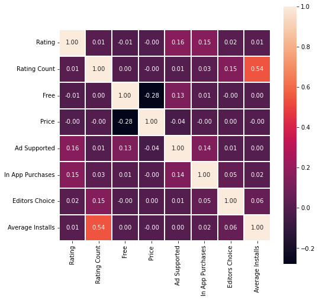

```python
# Correlation matrix plot
fig, axes = plt.subplots(figsize=(8, 8))
sns.heatmap(dataset.corr(),
            ax=axes,
            annot=True,
            linewidths=0.1,
            fmt='.2f',
            square=True)
plt.show()
```

## Now we are going Comparing Between the dataset before Handling missing values handling and after handling missing values

```
 BEFORE HANDLING MISSING VALUES CORRELATION HEATMAP  VS  AFTER HANDLING MISSING VALUES CORRELATION HEATMAP
```

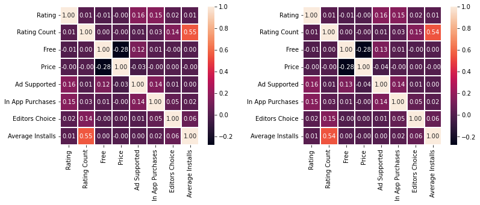

```python
print(color.BOLD + color.RED,
      "BEFORE HANDLING MISSING VALUES CORRELATION HEATMAP", color.END, "VS",
      color.BOLD + color.RED,
      "AFTER HANDLING MISSING VALUES CORRELATION HEATMAP", color.END)
f, axes = plt.subplots(1, 2, figsize=(12, 4))
#sns.set_style("white")
plt.subplots_adjust(left=0.1,
                    bottom=0.1,
                    right=0.9,
                    top=0.9,
                    wspace=0.4,
                    hspace=0.4)
for ix, m in enumerate([dataset3, dataset]):
    sns.heatmap(m.corr(),
                ax=axes[ix],
                annot=True,
                linewidths=0.1,
                fmt='.2f',
                square=True)
```

```python
print(
    color.BOLD + color.BLUE,
    "Therefore, from the above correlation matrix comparision between",
    color.RED,
    "\"BEFORE HANDLING MISSING VALUES CORRELATION HEATMAP\"",
    color.BLUE,
    "VS",
    color.RED,
    "\"AFTER HANDLING MISSING VALUES CORRELATION HEATMAP\"",
    color.BLUE,
    "We can conclude that there is no effect of missing value handling on the data because these values after handling missing values are not effecting the data and hence the missing value being imputed in the dataset can be used FURTHER...",
    sep='')
```

```
Therefore, from the above correlation matrix comparision between"BEFORE HANDLING MISSING VALUES CORRELATION HEATMAP"VS"AFTER HANDLING MISSING VALUES CORRELATION HEATMAP"We can conclude that there is no effect of missing value handling on the data because these values after handling missing values ar…
```

# Encoding and Formatting

```python
datasetnomiss[datasetnomiss['Content Rating'] == "Adults only 18+"]
```

|  | App Name | Category | Rating | Rating Count | Free | Price | Currency | Size | Minimum Android | Released | Last Updated | Content Rating | Ad Supported | In App Purchases | Editors Choice | Average Installs |
| --- | --- | --- | --- | --- | --- | --- | --- | --- | --- | --- | --- | --- | --- | --- | --- | --- |
| 10846 | PlayLive! - Casino & Slots | Entertainment | 0.0 | 0.0 | True | 0.0 | XXX | 9.6M | 5.0 and up | May 20, 2021 | May 20, 2021 | Adults only 18+ | False | False | False | 566.0 |
| 23610 | Playzee | Casino | 1.9 | 12.0 | True | 0.0 | USD | 3.3M | 4.1 and up | Mar 17, 2019 | Mar 17, 2019 | Adults only 18+ | False | False | False | 1149.0 |
| 73177 | DraftKings - Daily Fantasy Sports for Cash | Sports | 4.5 | 81954.0 | True | 0.0 | USD | 61M | 5.0 and up | Apr 16, 2015 | Jun 07, 2021 | Adults only 18+ | True | False | False | 2876279.5 |
| 87348 | DJ Golden Star Entertainment Ferdinant Mix 2020 | Music & Audio | 4.3 | 70.0 | True | 0.0 | USD | 45M | 4.1 and up | Oct 13, 2019 | Oct 13, 2019 | Adults only 18+ | True | False | False | 5827.0 |
| 88867 | BetMGM Poker - New Jersey | Casino | 2.8 | 8.0 | True | 0.0 | USD | 194M | 5.0 and up | Mar 3, 2021 | Apr 22, 2021 | Adults only 18+ | False | False | False | 1587.0 |
| ... | ... | ... | ... | ... | ... | ... | ... | ... | ... | ... | ... | ... | ... | ... | ... | ... |
| 2212579 | Success Always Positive | Education | 0.0 | 0.0 | True | 0.0 | USD | 6.3M | 5.0 and up | Nov 14, 2019 | Nov 15, 2019 | Adults only 18+ | True | False | False | 584.5 |
| 2268983 | viivbook | Dating | 0.0 | 0.0 | True | 0.0 | USD | 79M | 4.4 and up | May 6, 2021 | Jun 07, 2021 | Adults only 18+ | True | False | False | 16.0 |
| 2282499 | Star Movie Channel | Entertainment | 4.0 | 8.0 | True | 0.0 | USD | 4.9M | 4.0 and up | Jun 25, 2020 | Jun 25, 2020 | Adults only 18+ | True | False | False | 2082.0 |
| 2289741 | Foranta RiB | Events | 0.0 | 0.0 | True | 0.0 | USD | 9.6M | 4.1 and up | Jan 29, 2021 | Jan 29, 2021 | Adults only 18+ | False | False | False | 1.5 |
| 2312089 | Black Tie | Casino | 4.8 | 17.0 | True | 0.0 | USD | 35M | 2.3.3 and up | Jul 4, 2013 | May 16, 2014 | Adults only 18+ | True | False | False | 212.5 |

129 rows × 16 columns

```python
# 1) Change the RatingCount dtype to int
datasetencode['Rating Count'] = dataset['Rating Count'].astype(int)

# 2) Round up the Rating, Price, and Average Installs columns to 2 decimal points
datasetencode[['Rating', 'Price', 'Average Installs'
               ]] = dataset[['Rating', 'Price', 'Average Installs']].round(2)

# 3) Reformat release and update dates to show months and year (i.e. Release Month and Release Year, etc.)
datasetencode['Released'] = pd.to_datetime(dataset['Released'],
                                           format='%b %d, %Y')
datasetencode['Last Updated'] = pd.to_datetime(dataset['Last Updated'],
                                               format='%b %d, %Y')
```

```python
# 4) Change the 'Size' data in KB to MB and change the type 'object' to 'float'

# found value with '1,000+' in one of record, remove it from data_frame as uncertain whether it is 'M' or 'k'
sizes = [i for i in datasetencode['Size']]


def clean_sizes(sizes_list):
    """
    As sizes are represented in 'M' and 'k', we remove 'M'
    and convert 'k'/kilobytes into megabytes
    """
    cleaned_data = []
    for size in sizes_list:
        if 'M' in size:
            size = size.replace('M', '')
            size = size.replace(',', '')
            size = float(size)
        elif 'k' in size:
            size = size.replace('k', '')
            size = size.replace(',', '')
            size = float(size)
            size = size / 1024  # 1 megabyte = 1024 kilobytes
        elif 'G' in size:
            size = size.replace('G', '')
            size = size.replace(',', '')
            size = float(size)
            size = size * 1024  # 1 Gigabyte = 1024 Megabyte
        # representing 'Varies with device' with value 0
        elif 'Varies with device' in size:
            size = float(0)
        cleaned_data.append(size)
    return cleaned_data


datasetencode['Size'] = clean_sizes(sizes)
datasetencode['Size'] = datasetencode['Size'].astype(float)
```

```python
datasetencode.head()
```

|  | App Name | Category | Rating | Rating Count | Free | Price | Currency | Size | Minimum Android | Released | Last Updated | Content Rating | Ad Supported | In App Purchases | Editors Choice | Average Installs |
| --- | --- | --- | --- | --- | --- | --- | --- | --- | --- | --- | --- | --- | --- | --- | --- | --- |
| 0 | Gakondo | Adventure | 0.0 | 0 | True | 0.0 | USD | 10.0 | 7.1 and up | 2020-02-26 | 2020-02-26 | Everyone | False | False | False | 12.5 |
| 1 | Ampere Battery Info | Tools | 4.4 | 64 | True | 0.0 | USD | 2.9 | 5.0 and up | 2020-05-21 | 2021-05-06 | Everyone | True | False | False | 6331.0 |
| 2 | Vibook | Productivity | 0.0 | 0 | True | 0.0 | USD | 3.7 | 4.0.3 and up | 2019-08-09 | 2019-08-19 | Everyone | False | False | False | 54.0 |
| 3 | Smart City Trichy Public Service Vehicles 17UC... | Communication | 5.0 | 5 | True | 0.0 | USD | 1.8 | 4.0.3 and up | 2018-09-10 | 2018-10-13 | Everyone | True | False | False | 14.5 |
| 4 | GROW.me | Tools | 0.0 | 0 | True | 0.0 | USD | 6.2 | 4.1 and up | 2020-02-21 | 2018-11-12 | Everyone | False | False | False | 289.0 |

```python
dataset["Currency"].value_counts()
```

```
USD    2234107
XXX       1193
EUR          6
INR          5
GBP          3
CAD          2
VND          1
BRL          1
KRW          1
TRY          1
SGD          1
AUD          1
ZAR          1
Name: Currency, dtype: int64
```

```python
dataset['PriceRange'] = pd.cut(dataset['Price'],
                               bins=[0, 0.19, 9.99, 29.99, 410],
                               labels=['Free', 'Low', 'Mid', 'High'],
                               include_lowest=True)
dataset['PriceRange'].value_counts()
```

```
Free    2191406
Low       41054
Mid        2006
High        857
Name: PriceRange, dtype: int64
```

```python
print(dataset.Free.value_counts())
print("Apps that have Price = 0, have Free column True")
dataset.loc[(dataset.Price == 0) & (dataset.Free == False), 'Free'] = True
print(dataset.Free.value_counts())
```

```
True     2191386
False      43937
Name: Free, dtype: int64
Apps that have Price = 0, have Free column True
True     2191406
False      43917
Name: Free, dtype: int64
```

```python
# let's explore the content of few categorical variable
cat_feature = [
    "Category", "Free", "Price", "Currency", "Minimum Android", "Ad Supported",
    "In App Purchases", "Editors Choice"
]
for feature in cat_feature:
    print("Total count of unique values of ",
          color.UNDERLINE + color.BOLD + color.PURPLE + feature,
          ":",
          color.END,
          "\n",
          color.RED,
          len(dataset[feature].unique()),
          color.END,
          sep='')
    print("List of all the unique values of ",
          color.UNDERLINE + color.BOLD + color.PURPLE + feature,
          ":",
          color.END,
          "\n",
          dataset[feature].unique(),
          sep='')
    print("\n\n")
```

```
Total count of unique values of Category:
48
List of all the unique values of Category:
['Adventure' 'Tools' 'Productivity' 'Communication' 'Social'
 'Libraries & Demo' 'Lifestyle' 'Personalization' 'Racing'
 'Maps & Navigation' 'Travel & Local' 'Food & Drink' 'Books & Reference'
 'Medical' 'Puzzle' 'Entertainment' 'Arcade' 'Auto & Vehicles'
 'Photography' 'Health & Fitness' 'Education' 'Shopping' 'Board'
 'Music & Audio' 'Sports' 'Beauty' 'Business' 'Educational' 'Finance'
 'News & Magazines' 'Casual' 'Art & Design' 'House & Home' 'Card' 'Events'
 'Trivia' 'Weather' 'Strategy' 'Word' 'Video Players & Editors' 'Action'
 'Simulation' 'Music' 'Dating' 'Role Playing' 'Casino' 'Comics'
 'Parenting']



Total count of unique values of Free:
2
List of all the unique values of Free:
[ True False]



Total count of unique values of Price:
879
List of all the unique values of Price:
[0.00000000e+00 1.99000000e+00 4.99000000e+00 9.90000000e-01
 2.99000000e+00 3.49000000e+00 2.49900000e+01 4.49000000e+00
 3.99000000e+00 9.99900000e+01 1.49000000e+00 5.49000000e+00
 2.49000000e+00 4.19900000e+01 6.49000000e+00 5.29000000e+00
 1.99900000e+01 5.99000000e+00 9.99000000e+00 3.99900000e+01
 8.99000000e+00 2.89900000e+01 7.49000000e+00 2.00000000e+00
 7.99000000e+00 7.29500000e+01 4.89500000e+01 3.67000000e+00
 1.94214200e+00 5.31000000e+00 6.99000000e+00 5.49900000e+01
 3.23000000e+00 1.39900000e+01 1.07000000e+00 1.19900000e+01
 1.09900000e+01 3.08000000e+00 8.49000000e+00 1.19990000e+02
 2.99500000e+01 6.59900000e+01 1.00000000e+00 5.92000000e+00
 9.49000000e+00 3.59900000e+01 2.51900000e+01 3.29900000e+01
 5.00000000e+00 2.11000000e+00 3.99990000e+02 1.05000000e+00
 1.09000000e+00 4.39900000e+01 3.45000000e+00 1.86000000e+00
```

[output cut: 254 more lines]

```
[False  True]



Total count of unique values of In App Purchases:
2
List of all the unique values of In App Purchases:
[False  True]



Total count of unique values of Editors Choice:
2
List of all the unique values of Editors Choice:
[False  True]
```

```python
# Google Play Store Category Created In Apps And Games
# https://support.google.com/googleplay/android-developer/answer/9859673?hl=en#zippy=%2Cgames%2Capps
dataset_count = dataset['Category'].value_counts().to_frame()
dataset_count.reset_index(level=0, inplace=True)
mapping = {
    dataset_count.columns[0]: 'Category',
    dataset_count.columns[1]: 'Category_Count'
}
dataset_count.rename(columns=mapping, inplace=True)
print(dataset_count.sort_values(by="Category", ascending=True))
```

```
                   Category  Category_Count
23                   Action           26487
25                Adventure           22461
14                   Arcade           52222
28             Art & Design           18238
29          Auto & Vehicles           16879
34                   Beauty           11424
35                    Board           10315
5         Books & Reference          115397
3                  Business          136050
40                     Card            7896
43                   Casino            4907
16                   Casual           48671
47                   Comics            2762
17            Communication           45969
```

[output cut: 34 more lines]

# Visualization

```python
dataset = datasetencode
```

```python
apps = [
    "Art & Design", "Auto & Vehicles", "Beauty", "Books & Reference",
    "Business", "Comics", "Communication", "Dating", "Education",
    "Entertainment", "Events", "Finance", "Food & Drink", "Health & Fitness",
    "House & Home", "Libraries & Demo", "Lifestyle", "Maps & Navigation",
    "Medical", "Music & Audio", "News & Magazines", "Parenting",
    "Personalization", "Photography", "Productivity", "Shopping", "Social",
    "Sports", "Tools", "Travel & Local", "Video Players & Editors", "Weather"
]
appdf = dataset[dataset['Category'].isin(apps)]
appdf.head()
```

|  | App Name | Category | Rating | Rating Count | Free | Price | Currency | Size | Minimum Android | Released | Last Updated | Content Rating | Ad Supported | In App Purchases | Editors Choice | Average Installs |
| --- | --- | --- | --- | --- | --- | --- | --- | --- | --- | --- | --- | --- | --- | --- | --- | --- |
| 1 | Ampere Battery Info | Tools | 4.4 | 64 | True | 0.0 | USD | 2.9 | 5.0 and up | 2020-05-21 | 2021-05-06 | Everyone | True | False | False | 6331.0 |
| 2 | Vibook | Productivity | 0.0 | 0 | True | 0.0 | USD | 3.7 | 4.0.3 and up | 2019-08-09 | 2019-08-19 | Everyone | False | False | False | 54.0 |
| 3 | Smart City Trichy Public Service Vehicles 17UC... | Communication | 5.0 | 5 | True | 0.0 | USD | 1.8 | 4.0.3 and up | 2018-09-10 | 2018-10-13 | Everyone | True | False | False | 14.5 |
| 4 | GROW.me | Tools | 0.0 | 0 | True | 0.0 | USD | 6.2 | 4.1 and up | 2020-02-21 | 2018-11-12 | Everyone | False | False | False | 289.0 |
| 5 | IMOCCI | Social | 0.0 | 0 | True | 0.0 | USD | 46.0 | 6.0 and up | 2018-12-24 | 2019-12-20 | Teen | False | True | False | 69.5 |

```python
games = [
    "Action", "Adventure", "Arcade", "Board", "Card", "Casino", "Casual",
    "Educational", "Music", "Puzzle", "Racing", "Role Playing", "Simulation",
    "Sports", "Strategy", "Trivia", "Word"
]
gamesdf = dataset[dataset['Category'].isin(games)]
gamesdf.head()
```

|  | App Name | Category | Rating | Rating Count | Free | Price | Currency | Size | Minimum Android | Released | Last Updated | Content Rating | Ad Supported | In App Purchases | Editors Choice | Average Installs |
| --- | --- | --- | --- | --- | --- | --- | --- | --- | --- | --- | --- | --- | --- | --- | --- | --- |
| 0 | Gakondo | Adventure | 0.0 | 0 | True | 0.0 | USD | 10.0 | 7.1 and up | 2020-02-26 | 2020-02-26 | Everyone | False | False | False | 12.5 |
| 10 | Dodge The Cars! | Racing | 4.9 | 55 | True | 0.0 | USD | 51.0 | 4.4 and up | 2020-07-30 | 2020-07-30 | Everyone | False | False | False | 214.5 |
| 22 | Block Fill: Puzzle Game | Puzzle | 4.4 | 211 | True | 0.0 | USD | 16.0 | 5.0 and up | 2020-03-13 | 2020-05-11 | Everyone | True | True | False | 12735.5 |
| 25 | Sticky Ball | Arcade | 4.6 | 11 | True | 0.0 | USD | 25.0 | 4.1 and up | 2018-03-05 | 2018-03-26 | Everyone | True | True | False | 126.0 |
| 26 | CUBIC RUNNER | Arcade | 0.0 | 0 | True | 0.0 | USD | 16.0 | 4.0 and up | 2015-04-01 | 2015-04-16 | Everyone | True | True | False | 1034.0 |

```python
# Overall Population of category
sns.set_style('darkgrid')
categorydataset_column = [
    "Actual dataset", "Non-gaming dataset", "Gamaing dataset"
]
layout = widgets.Layout(width='auto', height='40px')  #set width and height
dd = widgets.Dropdown(options=categorydataset_column,
                      value=categorydataset_column[0],
                      description="Select Category: ",
                      style={'description_width': 'initial'},
                      display='block',
                      flex_flow='column',
                      align_items='stretch',
                      layout=layout)


def draw_countplot(column):
    if column == "Actual dataset":
        dt = dataset
    elif column == "Non-gaming dataset":
        dt = appdf
    elif column == "Gamaing dataset":
        dt = gamesdf
    plt.figure(figsize=(26, 14))
    chart = sns.countplot(x='Category',
                          data=dt,
                          order=dt['Category'].value_counts().index)
    chart.set_xlabel("Category", fontsize=25)
    chart.set_ylabel("Count", fontsize=25)
    chart.set_title("Overall Population of %s " % column, fontsize=30)
    t = chart.set_xticklabels(chart.get_xticklabels(),
                              rotation=80,
                              horizontalalignment='center')
    t = chart.get_xticklabels()


interact(draw_countplot, column=dd)
```

```
interactive(children=(Dropdown(description='Select Category: ', layout=Layout(height='40px', width='auto'), op…
```

```
<function __main__.draw_countplot(column)>
```

```python
# Released Year Wise Population of Category
# Category Wise number of applications Released per year selected
year_column = np.unique(dataset['Released'].dt.year)
dd = widgets.Dropdown(options=year_column,
                      value=year_column[0],
                      description="Select Year: ",
                      style={'description_width': 'initial'})


def draw_countplot(column):
    part_year = dataset.loc[dataset['Released'].dt.year == column]
    plt.figure(figsize=(26, 14))
    p = sns.countplot(data=part_year,
                      x='Category',
                      order=part_year['Category'].value_counts().index)
    p.set_xlabel("Category", fontsize=20)
    p.set_ylabel("Count", fontsize=20)
    p.set_title("%d year Categorical CountPlot" % column, fontsize=30)
    t = p.set_xticklabels(p.get_xticklabels(),
                          rotation=85,
                          horizontalalignment='center',
                          fontsize=14)


interact(draw_countplot, column=dd)
```

```
interactive(children=(Dropdown(description='Select Year: ', options=(2010, 2011, 2012, 2013, 2014, 2015, 2016,…
```

```
<function __main__.draw_countplot(column)>
```

```python
# Category Wise number of applications Released per year selected for only usual Applications i.e non-gaming applications
year_column = np.unique(appdf['Released'].dt.year)
dd = widgets.Dropdown(options=year_column,
                      value=year_column[0],
                      description="Select Year: ",
                      style={'description_width': 'initial'})


def draw_countplot(column):
    part_year = appdf.loc[appdf['Released'].dt.year == column]
    plt.figure(figsize=(26, 14))
    p = sns.countplot(data=part_year,
                      x='Category',
                      order=part_year['Category'].value_counts().index)
    p.set_xlabel("Category (Non-gaming Applications Only)", fontsize=20)
    p.set_ylabel("Count", fontsize=20)
    p.set_title("%d year Categorical CountPlot for non-gaming applications" %
                column,
                fontsize=30)
    t = p.set_xticklabels(p.get_xticklabels(),
                          rotation=80,
                          horizontalalignment='center',
                          fontsize=16)


interact(draw_countplot, column=dd)
```

```
interactive(children=(Dropdown(description='Select Year: ', options=(2010, 2011, 2012, 2013, 2014, 2015, 2016,…
```

```
<function __main__.draw_countplot(column)>
```

```python
# Category Wise number of applications Released per year selected for only Gaming Applications
year_column = np.unique(gamesdf['Released'].dt.year)
dd = widgets.Dropdown(options=year_column,
                      value=year_column[0],
                      description="Select Year: ",
                      style={'description_width': 'initial'})


def draw_countplot(column):
    part_year = gamesdf.loc[gamesdf['Released'].dt.year == column]
    #part_year=part_year.sort_values(by='Released',ascending = False)
    plt.figure(figsize=(26, 14))
    p = sns.countplot(data=part_year,
                      x='Category',
                      order=part_year['Category'].value_counts().index)
    p.set_xlabel("Category (Gaming Applications Only)", fontsize=20)
    p.set_ylabel("Count", fontsize=20)
    p.set_title("%d year Categorical CountPlot for gaming applications" %
                column,
                fontsize=30)
    t = p.set_xticklabels(p.get_xticklabels(),
                          rotation=0,
                          horizontalalignment='center',
                          fontsize=14)


interact(draw_countplot, column=dd)
```

```
interactive(children=(Dropdown(description='Select Year: ', options=(2010, 2011, 2012, 2013, 2014, 2015, 2016,…
```

```
<function __main__.draw_countplot(column)>
```

#### From the above graph we can conclude the following points for "Count Vs Category for gaming dataset only " countplot:

1. For year 2010:
   - Category with maximum number of applications launched - "Sports" followed by "Puzzle", "Casual", "Arcade" etc..
   - Category with minimum number of applications launched - "Adventure" followed by "Trivia", "Casino","Strategy" etc..
2. For year 2011:
   - Category with maximum number of applications launched - "Sports" followed by "Board", "Puzzle", "Card", "Strategy" etc..
   - Category with minimum number of applications launched - "Adventure" followed by "Racing", "Word", "Educational", "Casino" etc..

     In the Year 2015 we can see that Puzzle game has seen a rise with most number of applications count and one of the reason for this can be "Candy Crush" released in 2015 due to which there were many other developers bringing in many other puzzle games which was popular for that period of year and also to give a competition to the popular game and get popular.

```python
# total installs for each category
categorydataset_column = [
    "Actual dataset", "Non-gaming dataset", "Gamaing dataset"
]
dd = widgets.Dropdown(options=categorydataset_column,
                      value=categorydataset_column[0],
                      description="Select Category: ",
                      style={'description_width': 'initial'})


def draw_countplot(column):
    if column == "Actual dataset":
        total_installs_per_category = dataset.groupby(
            'Category')['Average Installs'].sum()
        total_installs_sorted = total_installs_per_category.sort_values(
            ascending=False)
    elif column == "Non-gaming dataset":
        total_installs_per_category = appdf.groupby(
            'Category')['Average Installs'].sum()
        total_installs_sorted = total_installs_per_category.sort_values(
            ascending=False).nlargest(32)
    elif column == "Gamaing dataset":
        total_installs_per_category = gamesdf.groupby(
            'Category')['Average Installs'].sum()
        total_installs_sorted = total_installs_per_category.sort_values(
            ascending=False).nlargest(32)
    plt.figure(figsize=(26, 14))
    p = sns.barplot(y=total_installs_sorted.index,
                    x=total_installs_sorted.values)
    p.bar_label(p.containers[0])
    p.set_title("Total Installs per Category", fontsize=30)
    p.set_xlabel("Number of Installs", fontsize=20)
    p.set_ylabel("Category", fontsize=20)
    t = p.set_yticklabels(p.get_yticklabels(),
                          rotation=0,
                          horizontalalignment='right',
                          fontsize=15)


interact(draw_countplot, column=dd)
```

```
interactive(children=(Dropdown(description='Select Category: ', options=('Actual dataset', 'Non-gaming dataset…
```

```
<function __main__.draw_countplot(column)>
```

### Visualizing Number of applications released with respect to different years for "Actual dataset", "Non-gaming dataset" and "Gamaing dataset

```python
categorydataset_column = [
    "Actual dataset", "Non-gaming dataset", "Gamaing dataset"
]
dd = widgets.Dropdown(options=categorydataset_column,
                      value=categorydataset_column[0],
                      description="Select Category: ",
                      style={'description_width': 'initial'})


def draw_countplot(column):
    if column == "Actual dataset":
        #get the release year
        years = dataset['Released'].apply(lambda x: x.year)
    elif column == "Non-gaming dataset":
        #get the release year
        years = appdf['Released'].apply(lambda x: x.year)
    elif column == "Gamaing dataset":
        #get the release year
        years = gamesdf['Released'].apply(lambda x: x.year)
    release_years = years.value_counts()
    release_years = release_years.reset_index()
    release_years.rename(columns={"index": "year"}, inplace=True)
    release_years.sort_values(by='year', ascending=False, inplace=True)

    #plot the graph
    plt.plot(release_years['year'], release_years['Released'], marker='o')
    plt.xlabel('Year')
    plt.ylabel('Number of Apps Released')
    plt.xticks([i for i in range(2010, 2022)], rotation=30)
    plt.xlim([2010, 2020])
    plt.title('Number of Apps Released per Year')
    plt.show()


interact(draw_countplot, column=dd)
```

```
interactive(children=(Dropdown(description='Select Category: ', options=('Actual dataset', 'Non-gaming dataset…
```

```
<function __main__.draw_countplot(column)>
```

### Visualizing Paid and free application with respect to different content rating

```python
# Content Rating for FREE and PAID Apps
categorydataset_column = [
    "Actual dataset", "Non-gaming dataset", "Gamaing dataset"
]
dd = widgets.Dropdown(options=categorydataset_column,
                      value=categorydataset_column[0],
                      description="Select Category: ",
                      style={'description_width': 'initial'})


def draw_countplot(column):
    if column == "Actual dataset":
        Type = np.where(dataset['Free'] == True, 'Free', 'Paid')
        plt.figure(figsize=(10, 10))
        ax = sns.countplot(x="Content Rating", data=dataset, hue=Type)
        plt.title("ContentRating in Free and Paid")
        for p in ax.patches:
            ax.annotate(p.get_height(),
                        (p.get_x() + p.get_width() / 2, p.get_height()),
                        ha='center',
                        size=12)
        plt.show()
    elif column == "Non-gaming dataset":
        Type = np.where(appdf['Free'] == True, 'Free', 'Paid')
        plt.figure(figsize=(10, 10))
        ax = sns.countplot(x="Content Rating", data=appdf, hue=Type)
        plt.title("ContentRating in Free and Paid")
        for p in ax.patches:
            ax.annotate(p.get_height(),
                        (p.get_x() + p.get_width() / 2, p.get_height()),
                        ha='center',
                        size=12)
        plt.show()
    elif column == "Gamaing dataset":
        Type = np.where(gamesdf['Free'] == True, 'Free', 'Paid')
        plt.figure(figsize=(10, 10))
        ax = sns.countplot(x="Content Rating", data=gamedf, hue=Type)
        plt.title("ContentRating in Free and Paid")
        for p in ax.patches:
            ax.annotate(p.get_height(),
                        (p.get_x() + p.get_width() / 2, p.get_height()),
                        ha='center',
                        size=12)
        plt.show()


interact(draw_countplot, column=dd)
```

```
interactive(children=(Dropdown(description='Select Category: ', options=('Actual dataset', 'Non-gaming dataset…
```

```
<function __main__.draw_countplot(column)>
```

```
From the above plot we can clearly see that Content Rating with the value "Everyone" is dominating Where Free Applications are dominating to a great extent than paid applications.

We would now try to visualize the count of Content Rating for FREE and PAID Apps by excluding the "Everyone" and Visualizing for the rest of the other apps.
```

```python
# Content Rating for FREE and PAID Apps
z = ["Everyone"]
categorydataset_column = [
    "Actual dataset", "Non-gaming dataset", "Gamaing dataset"
]
dd = widgets.Dropdown(options=categorydataset_column,
                      value=categorydataset_column[0],
                      description="Select Category: ",
                      style={'description_width': 'initial'})


def draw_countplot(column):
    if column == "Actual dataset":
        dt = dataset
    elif column == "Non-gaming dataset":
        dt = appdf
    elif column == "Gamaing dataset":
        dt = gamesdf
    dt = dt.loc[dt['Content Rating'] != "Everyone"]
    Type = np.where(dt['Free'] == True, 'Free', 'Paid')
    plt.figure(figsize=(10, 10))
    ax = sns.countplot(x="Content Rating", data=dt, hue=Type)
    plt.title("ContentRating in Free and Paid")
    for p in ax.patches:
        ax.annotate(p.get_height(),
                    (p.get_x() + p.get_width() / 2, p.get_height()),
                    ha='center',
                    size=12)
    plt.show()


interact(draw_countplot, column=dd)
```

```
interactive(children=(Dropdown(description='Select Category: ', options=('Actual dataset', 'Non-gaming dataset…
```

```
<function __main__.draw_countplot(column)>
```

```python
m = dataset["Rating Count"].max()
dataset[dataset["Rating Count"] == m]
```

|  | App Name | Category | Rating | Rating Count | Free | Price | Currency | Size | Minimum Android | Released | Last Updated | Content Rating | Ad Supported | In App Purchases | Editors Choice | Average Installs |
| --- | --- | --- | --- | --- | --- | --- | --- | --- | --- | --- | --- | --- | --- | --- | --- | --- |
| 385468 | WhatsApp Messenger | Communication | 4.0 | 138557570 | True | 0.0 | USD | 0.0 | Varies with device | 2010-10-18 | 2021-06-09 | Everyone | False | False | True | 5.632819e+09 |

```
from the above table we can see that whatsapp has most number of Rating Count i.e many people have rated Whatsapp in the google play store.
```

### Visualizing Number of app releases per year with respect to the Content Rating

```python
print(dataset['Content Rating'].unique())
```

```
['Everyone' 'Teen' 'Mature 17+' 'Everyone 10+' 'Adults only 18+' 'Unrated']
```

```
Barplot and Respective Line plot for "Number OF Apps Released" VS "Year" for Everyone
```

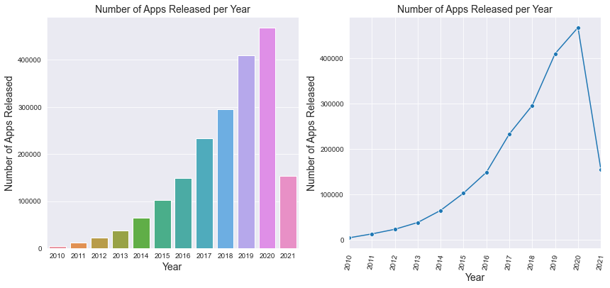

```
Barplot and Respective Line plot for "Number OF Apps Released" VS "Year" for Teen
```

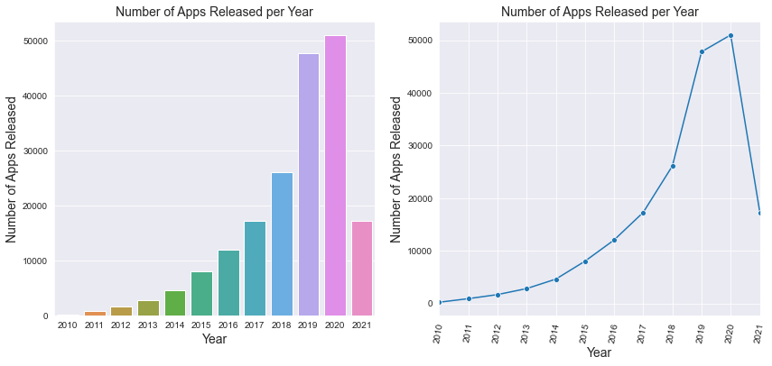

```
Barplot and Respective Line plot for "Number OF Apps Released" VS "Year" for Mature 17+
```

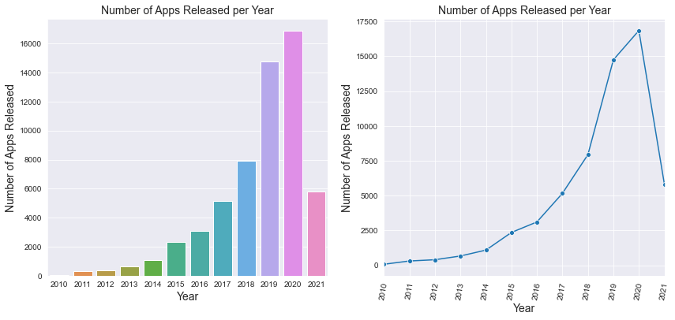

```
Barplot and Respective Line plot for "Number OF Apps Released" VS "Year" for Everyone 10+
```

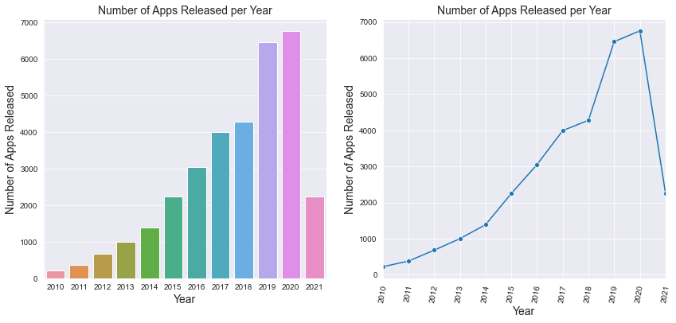

```
Barplot and Respective Line plot for "Number OF Apps Released" VS "Year" for Adults only 18+
```

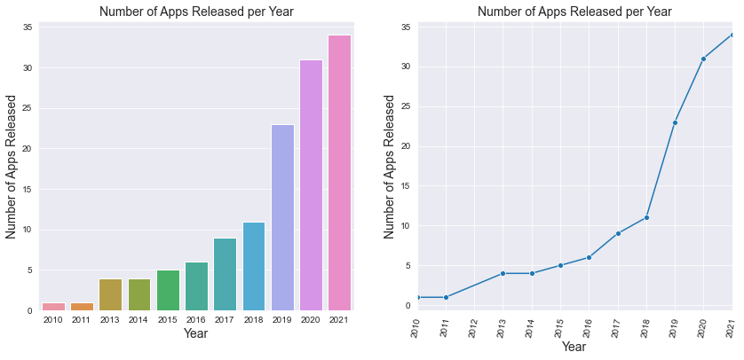

```
Barplot and Respective Line plot for "Number OF Apps Released" VS "Year" for Unrated
```

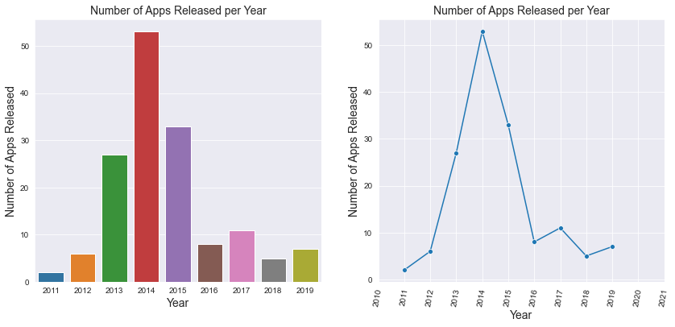

```python
numerical = dataset['Content Rating'].unique()
for col in numerical:
    dt = dataset[dataset["Content Rating"] == col]
    fig, ax = plt.subplots(1, 2, figsize=(14, 6))
    #sns.histplot(data=dataset, x="", ax=ax[0])
    #sns.boxplot(data=dataset, x="Content Rating", ax=ax[1]);
    #get the release year
    years = dt['Released'].apply(lambda x: x.year)
    release_years = years.value_counts()
    release_years = release_years.reset_index()
    release_years.rename(columns={"index": "year"}, inplace=True)
    release_years.sort_values(by='year', ascending=False, inplace=True)

    #plot the graph
    print(
        color.BOLD + color.RED,
        "Barplot and Respective Line plot for \"Number OF Apps Released\" VS \"Year\" for ",
        color.BLUE + color.UNDERLINE,
        "%s" % col,
        color.END,
        sep='')
    br = sns.barplot(x=release_years['year'],
                     y=release_years['Released'],
                     data=dataset,
                     ax=ax[0])
    #br.set(xlabel='common xlabel', ylabel='common ylabel')
    br.axes.set_title("Number of Apps Released per Year", fontsize=14)
    br.set_xlabel(xlabel='Year', fontsize=14)
    br.set_ylabel(ylabel='Number of Apps Released', fontsize=14)
    brln = sns.lineplot(x=release_years['year'],
                        y=release_years['Released'],
                        data=dataset,
                        marker='o',
                        ax=ax[1])
    brln.axes.set_title("Number of Apps Released per Year", fontsize=14)
    brln.set_xlabel(xlabel='Year', fontsize=14)
    brln.set_ylabel(ylabel='Number of Apps Released', fontsize=14)
    plt.xticks([i for i in range(2010, 2022)])
    plt.xticks(rotation=80)
    plt.xlim([2010, 2021])
    plt.show()
```

[output not shown]

```python
recent = dataset.iloc[dataset["Released"].argmax()]  # returns a Series
print("The Most recent released app data which is in the dataset in use is ",
      color.BOLD + color.RED,
      recent["Released"],
      color.END,
      sep='')
```

```
The Most recent released app data which is in the dataset in use is 2021-06-16 00:00:00
```

```
Barplot and Respective Line plot for "Number OF Apps Released" VS "Year" for Everyone
```

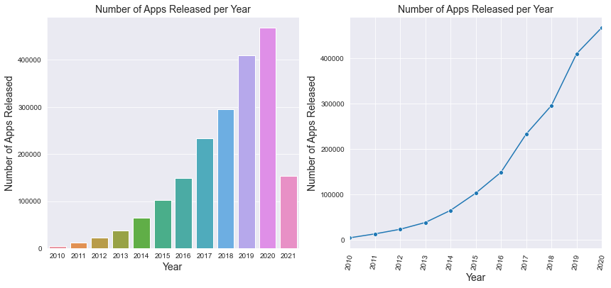

```
Barplot and Respective Line plot for "Number OF Apps Released" VS "Year" for Teen
```

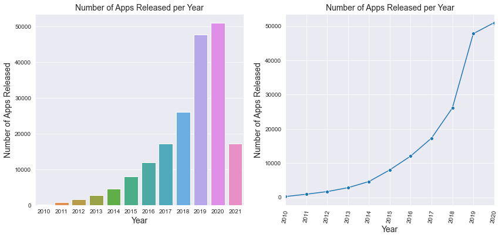

```
Barplot and Respective Line plot for "Number OF Apps Released" VS "Year" for Mature 17+
```

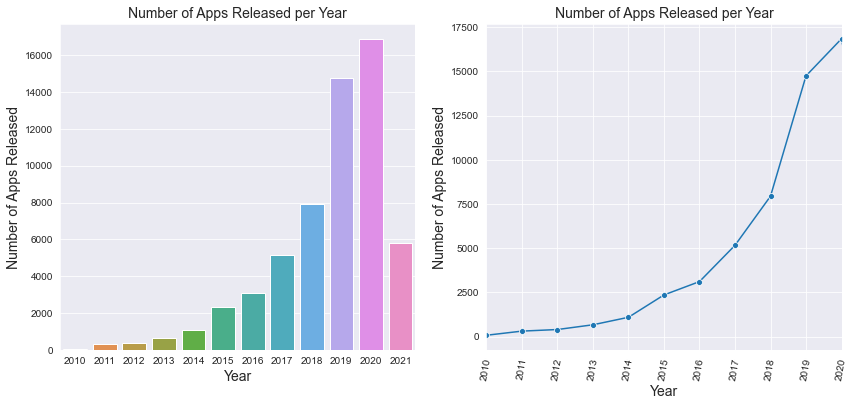

```
Barplot and Respective Line plot for "Number OF Apps Released" VS "Year" for Everyone 10+
```

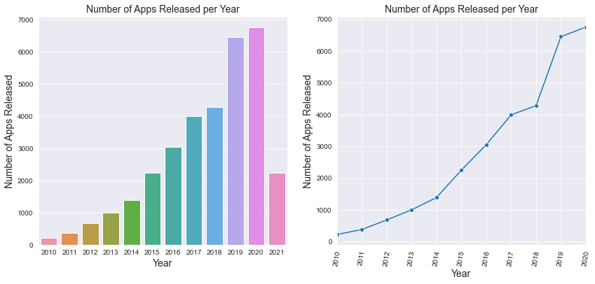

```
Barplot and Respective Line plot for "Number OF Apps Released" VS "Year" for Adults only 18+
```

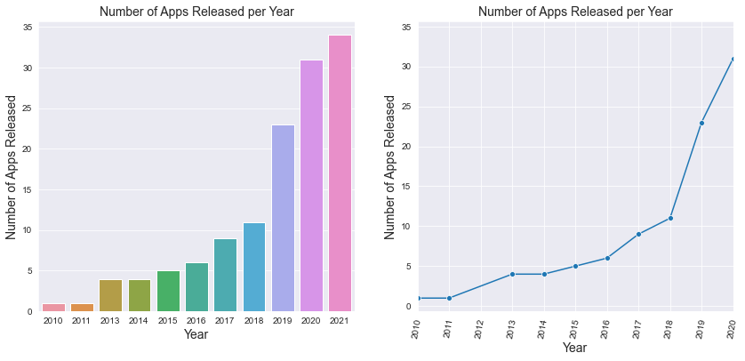

```
Barplot and Respective Line plot for "Number OF Apps Released" VS "Year" for Unrated
```

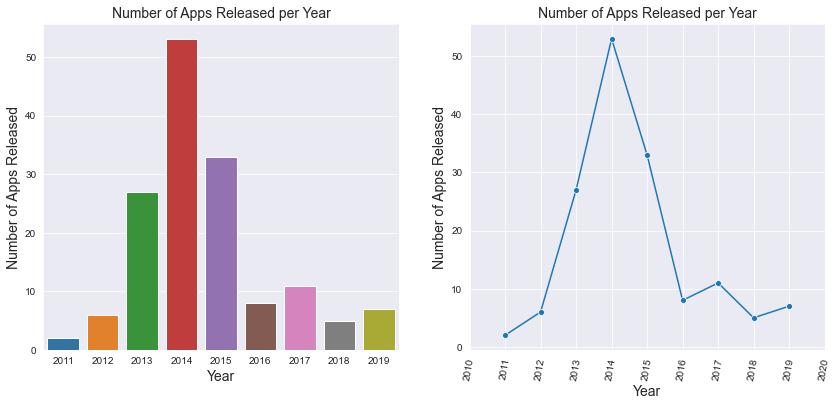

```python
numerical = dataset['Content Rating'].unique()
for col in numerical:
    dt = dataset[dataset["Content Rating"] == col]
    fig, ax = plt.subplots(1, 2, figsize=(14, 6))
    #sns.histplot(data=dataset, x="", ax=ax[0])
    #sns.boxplot(data=dataset, x="Content Rating", ax=ax[1]);
    #get the release year
    years = dt['Released'].apply(lambda x: x.year)
    release_years = years.value_counts()
    release_years = release_years.reset_index()
    release_years.rename(columns={"index": "year"}, inplace=True)
    release_years.sort_values(by='year', ascending=False, inplace=True)

    #plot the graph
    print(
        color.BOLD + color.RED,
        "Barplot and Respective Line plot for \"Number OF Apps Released\" VS \"Year\" for ",
        color.BLUE + color.UNDERLINE,
        "%s" % col,
        color.END,
        sep='')
    br = sns.barplot(x=release_years['year'],
                     y=release_years['Released'],
                     data=dataset,
                     ax=ax[0])
    #br.set(xlabel='common xlabel', ylabel='common ylabel')
    br.axes.set_title("Number of Apps Released per Year", fontsize=14)
    br.set_xlabel(xlabel='Year', fontsize=14)
    br.set_ylabel(ylabel='Number of Apps Released', fontsize=14)
    brln = sns.lineplot(x=release_years['year'],
                        y=release_years['Released'],
                        data=dataset,
                        marker='o',
                        ax=ax[1])
    brln.axes.set_title("Number of Apps Released per Year", fontsize=14)
    brln.set_xlabel(xlabel='Year', fontsize=14)
    brln.set_ylabel(ylabel='Number of Apps Released', fontsize=14)
    plt.xticks([i for i in range(2010, 2022)])
    plt.xticks(rotation=80)
    plt.xlim([2010, 2020])
    plt.show()
```

[output not shown]

```python
# getting the largest increase
numerical = dataset['Content Rating'].unique()
for col in numerical:
    dt = dataset[dataset["Content Rating"] == col]
    years = dt['Released'].apply(lambda x: x.year)
    release_years = years.value_counts()
    release_years = release_years.reset_index()
    release_years.rename(columns={"index": "year"}, inplace=True)
    release_years.sort_values(by='year', ascending=False, inplace=True)
    print(color.BOLD + color.RED,
          "Largest Increase for \"Number OF Apps Released\" VS \"Year\" for ",
          color.BLUE + color.UNDERLINE,
          "%s" % col,
          " = " + color.PURPLE,
          int(release_years[release_years['year'] == 2019]['Released']) -
          int(release_years[release_years['year'] == 2018]['Released']),
          color.END,
          sep='')
    print()
```

```
Largest Increase for "Number OF Apps Released" VS "Year" for Everyone = 114334

Largest Increase for "Number OF Apps Released" VS "Year" for Teen = 21679

Largest Increase for "Number OF Apps Released" VS "Year" for Mature 17+ = 6804

Largest Increase for "Number OF Apps Released" VS "Year" for Everyone 10+ = 2175

Largest Increase for "Number OF Apps Released" VS "Year" for Adults only 18+ = 12

Largest Increase for "Number OF Apps Released" VS "Year" for Unrated = 2
```

```
In the Number of release VS year for content rating of type "Everyone", "Teen", "Mature 17+", "Everyone 10+" and "Adults only 18+" saw a exponential increase in the year 2018-2019 compared to other years.
The reason for this can be many but few that can be considered is:

1. Release of "Android App Bundle" feature by google in 2018 with which the developer can easily deliver a great experience in a smaller app size, bought in some new feature in google console like internal test track, pre-launch report, Android vitals. this Release-fearture also bought an Improvement in store performance and user acquisition.
These Release-feature is very important for a developer to release and maintain the app without any fail for a long time. Like the beta testing which was an issue for release can be solved by using the Internal test track that helps to push the app to up to 100 internal testers in seconds before you release them to alpha, beta, or production. and pre-launch report that summarizes issues found in alpha or beta versions of the app, based on automated testing on popular devices in Firebase Test Lab, the Android vitals also help in analyzing data about startup time and permission denials in addition to battery, rendering, and stability. Similarly many other feature of this release-feature helped developer to Avoid mstakes before and after launch of the android apps.

2. The second reason can be the SDG's (Sustainable Development Goals) supported by UNSC a collection of 17 interlinked global goals designed to be a "blueprint to achieve a better and more sustainable future for all". Where SDG was established in 2015 but two years later (6 July 2017) the SDGs were made more "actionable" by a UN Resolution adopted by the General Assembly.
so some of this goals like Decent Work and Economic Growth, Industry, Innovation and Infrastructure, Industry, Innovation and Infrastructure, Quality Education, must have helped in the release of the apps.



reference --> https://android-developers.googleblog.com/2018/05/io-2018-everything-new-in-google-play.html
              https://www.clariontech.com/blog/why-30-of-mobile-apps-fail-within-the-first-18-months-post-launch-and-how-to-avoid-it
              https://www.startupgrind.com/blog/9999-in-10000-mobile-apps-will-fail-heres-why/
```

```
In the Number of release VS year for content rating of type Unrated we can clearly see that after 2014 the number of apps releases decreased and then after 2019 it eventually got 0.
The reason for this change is the new global age-rating system which was added to the Google Play store which says Existing apps where developers have not completed the questionnaire will be marked as unrated on the Google Play store, which may mean they are blocked in certain countries. From May-2015 , developers submitting new apps or updating older ones will be required to complete the questionnaire. Where all the apps will be required to carry a rating in order to be accessible in Google Play.

where as the the content rating description in googleplay app is given as "Warning - content has not yet been rated. Unrated apps may potentially contain content appropriate for mature audiences only."
and also a stackoverflow question of June,2015 of the same year suggest that content rating as "Unrated" was not helping the developer to reach the audience in any possible way.
Hence we can see the drop in the unrated app releases and eventually with no apps with the content-rating as "Unrated"

reference --> https://www.cnet.com/tech/mobile/google-play-adds-app-ratings-to-inform-users-on-content/
              https://www.theguardian.com/technology/2015/mar/17/android-apps-age-rating-system-google-play
              https://support.google.com/googleplay/android-developer/answer/9859655?hl=en#zippy=%2Cunrated%2Crefused-classification
              https://stackoverflow.com/questions/30465050/content-rating-removed-your-app-content-rating-was-removed-please-submit-a-new/30691962#30691962
```

### Boxplot for rating for each category

```python
categorydataset_column = [
    "Actual dataset", "Non-gaming dataset", "Gamaing dataset"
]
dd = widgets.Dropdown(options=categorydataset_column,
                      value=categorydataset_column[0],
                      description="Select Category: ",
                      style={'description_width': 'initial'})


def draw_countplot(column):
    if column == "Actual dataset":
        dt = dataset
    elif column == "Non-gaming dataset":
        dt = appdf
    elif column == "Gamaing dataset":
        dt = gamesdf
    plt.figure(figsize=(12, 12))

    median_ratings = dt[dt['Rating'] > 0].groupby(
        'Category')['Rating'].median()[:]
    plot_order = median_ratings.sort_values(ascending=False).index
    plt.title('Ratings per Category for %s' % column)
    sns.boxplot(x='Rating',
                y='Category',
                data=dt[dt['Rating'] > 0],
                order=plot_order)

    plt.show()


interact(draw_countplot, column=dd)
```

```
interactive(children=(Dropdown(description='Select Category: ', options=('Actual dataset', 'Non-gaming dataset…
```

```
<function __main__.draw_countplot(column)>
```

```
the conclusion for all three(Actual dataset, Non-gaming dataset, Gaming dataset) can be made with the number of installs on the play store
Actual Dataset & Non-Gaming Dataset:
One thing to point out is the fact that the Events category holds the highest mean rating, while having the least number of installs on the Google Play Store (check the graph directly above). Actually, if you were to think about it, that would make perfect sense, since there are less number of apps that result in a regression of the rating to the mean, causing slightly 'inflated' ratings for categories with lesser apps (although this does not apply to most categories).

Gaming Dataset:
The above statement also applies for the gaming category of applications where Word category holds the highest mean rating, while being in the bottom for the number of installs on the Google Play Store
```

### Visualizing Number of Application for all the rating distribution.

```python
# show the distribution of rating for each category
categorydataset_column = [
    "Actual dataset", "Non-gaming dataset", "Gamaing dataset"
]
dd = widgets.Dropdown(options=categorydataset_column,
                      value=categorydataset_column[0],
                      description="Select Category: ",
                      style={'description_width': 'initial'})


def draw_countplot(column):
    if column == "Actual dataset":
        dt = dataset
    elif column == "Non-gaming dataset":
        dt = appdf
    elif column == "Gamaing dataset":
        dt = gamesdf
    plt.figure(figsize=(10, 5))
    sns.countplot(x='Rating', data=dt.loc[dt['Rating'] >= 0])
    plt.title('Rating Distribution')
    plt.xticks(rotation=90)
    plt.ylabel('Number of Apps')
    plt.show()


interact(draw_countplot, column=dd)
```

```
interactive(children=(Dropdown(description='Select Category: ', options=('Actual dataset', 'Non-gaming dataset…
```

```
<function __main__.draw_countplot(column)>
```

```
From the above graph we can clearly see that 0 does not make sense in visualizing the graph so we ignore the rating at 0 and visualize the graph for rating > 0
```

```python
# show the distribution of rating for each category
categorydataset_column = [
    "Actual dataset", "Non-gaming dataset", "Gamaing dataset"
]
dd = widgets.Dropdown(options=categorydataset_column,
                      value=categorydataset_column[0],
                      description="Select Category: ",
                      style={'description_width': 'initial'})


def draw_countplot(column):
    if column == "Actual dataset":
        dt = dataset
    elif column == "Non-gaming dataset":
        dt = appdf
    elif column == "Gamaing dataset":
        dt = gamesdf
    plt.figure(figsize=(10, 5))
    sns.countplot(x='Rating', data=dt.loc[dt['Rating'] > 0])
    plt.title('Rating Distribution')
    plt.xticks(rotation=90)
    plt.ylabel('Number of Apps')
    plt.show()


interact(draw_countplot, column=dd)
```

```
interactive(children=(Dropdown(description='Select Category: ', options=('Actual dataset', 'Non-gaming dataset…
```

```
<function __main__.draw_countplot(column)>
```

```python
dataset.info()
```

```
<class 'pandas.core.frame.DataFrame'>
Int64Index: 2235323 entries, 0 to 2312935
Data columns (total 16 columns):
 #   Column            Dtype
---  ------            -----
 0   App Name          object
 1   Category          object
 2   Rating            float64
 3   Rating Count      int32
 4   Free              bool
 5   Price             float64
 6   Currency          object
 7   Size              float64
 8   Minimum Android   object
 9   Released          datetime64[ns]
 10  Last Updated      datetime64[ns]
 11  Content Rating    object
 12  Ad Supported      bool
 13  In App Purchases  bool
 14  Editors Choice    bool
 15  Average Installs  float64
dtypes: bool(4), datetime64[ns](2), float64(4), int32(1), object(5)
memory usage: 221.7+ MB
```

### Visalizing the Free and Paid Applications in Google Play Store

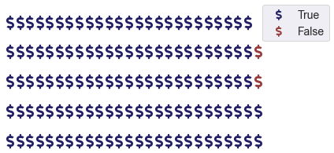

```python
rn = ["Free", "Paid"]
data = dict(dataset['Free'].value_counts(normalize=True).rename(
    map(lambda x: x, rn)).mul(100).round())
plt.figure(figsize=(40, 30))
fig = plt.figure(FigureClass=Waffle,
                 rows=5,
                 columns=26,
                 values=data,
                 colors=["#232066", "#983D3D"],
                 legend={
                     'loc': 'upper left',
                     'bbox_to_anchor': (1, 1.2),
                     'fontsize': 14
                 },
                 icons='dollar-sign',
                 icon_size=18,
                 rounding_rule='floor',
                 interval_ratio_x=2,
                 interval_ratio_y=8,
                 icon_legend=True)
plt.show()
```

```python
data = dataset['Free'].value_counts(normalize=True) * 100
data
```

```
True     98.034423
False     1.965577
Name: Free, dtype: float64
```

```
From the Above graph and calculated precentage we can see that there are more number of free applicartions in google play store compared to the paid application. This might be shocking because after all, earning money is the whole point right? Soo, if we consider earning then one would be shock to hear that the most of the revenue made by mobile applications is generally from free applications and this is done by including app monetization strategies like in-app purchases, which is equivalent to 98% of app revenue worldwide. This overwhelming amount of free apps on the Play Store signifies a major shift towards the freemium model and this is the reason why developers are building and releasing Androids apps.
reference --> https://appinventiv.com/blog/how-to-make-money-from-free-apps/
              https://appinventiv.com/blog/android-app-for-your-business/
              https://appinventiv.com/blog/google-play-store-statistics/
```

### Visulaizing the Category using WordCloud

```python
categorydataset_column = [
    "Actual dataset", "Non-gaming dataset", "Gamaing dataset"
]
dd = widgets.Dropdown(options=categorydataset_column,
                      value=categorydataset_column[0],
                      description="Select Category: ",
                      style={'description_width': 'initial'})


def draw_countplot(column):
    if column == "Actual dataset":
        dt = dataset
    elif column == "Non-gaming dataset":
        dt = appdf
    elif column == "Gamaing dataset":
        dt = gamesdf
    mask = np.array(Image.open('./GP_mask.jpg').convert('L'))
    mask_colors = ImageColorGenerator(mask)
    wc = WordCloud(max_font_size=250,
                   collocations=False,
                   max_words=1000,
                   width=mask.shape[1],
                   height=mask.shape[0],
                   background_color="white",
                   mask=mask).generate(' '.join(dt['Category'].replace(
                       ' ', '_', regex=True)))
    plt.figure(figsize=(20, 10))
    plt.imshow(wc, interpolation="bilinear")
    plt.axis("off")
    plt.tight_layout(pad=0)
    plt.show()
    plt.savefig('Category.png')


interact(draw_countplot, column=dd)
```

```
interactive(children=(Dropdown(description='Select Category: ', options=('Actual dataset', 'Non-gaming dataset…
```

```
<function __main__.draw_countplot(column)>
```